# Who’s Doing the Thinking?

Purposeful AI for learners, teachers, and researchers

Bodong Chen

cbd@upenn.edu

Penn GSE · Wonder Lab

## Introductions Hi, I’m Bodong

### Bodong Chen

Associate Professor, Learning Sciences & Technologies, Penn GSE

Wonder Lab

I study how people **build knowledge together**, and I build tools that **keep humans in charge** of that work.

**InkSpire** Reading scaffolds for instructors

**WonderBits** AI agents propose, students decide

**DataX** Data investigations of justice issues

“I’m less interested in *whether* students use AI than in who is doing the thinking, and who gets to shape the environment.”

## You, right now Most of you wear *three hats* at once

Learner

### Taking courses, reading, writing

What am I trying to *learn* here?

TA / Instructor

### Leading sections, designing tasks, giving feedback

What am I trying to *teach* here?

Researcher

### Collecting and analyzing data, building an argument

What counts as *my* judgment here?

The thread through all three: **start with pedagogy, not technology.** *Same principles can lead to different design outcomes.*

01 Where we are How AI has been implemented and experienced by students, educators, and researchers

## Where we are Adoption came *bottom-up* and *uneven*

1

### Students moved first

Often privately, with some anxiety about whether it’s allowed. Real help getting unstuck, and a pull toward offloading the part that *was* the learning.

2

### Institutions followed with policy

Detection and bans came first. Course-by-course rules still leave students guessing. Transparency norms help more than bans.

3

### Pedagogy is still catching up

Shifting toward “purposeful engagement,” but unevenly. AI on the *teaching* side (prep, scaffolds, feedback) gets far less attention.

## Where we are For researchers, AI is both *topic* and *tool*

Researcher

### What’s happening

- Coding qualitative data, literature work, discourse analysis
- In my lab: LLMs to evaluate the *promisingness* of ideas in knowledge-building discourse

Still open

### What isn’t settled

- Validity and reproducibility
- What counts as the researcher’s judgment
- Norms for AI in dissertation work are still forming, and advisors vary a lot

Most of what’s happened so far is AI being *dropped into* existing practices. The more interesting question is what practices we *design* around it.

02 Same principles, different outcomes Where the benefits are real: when AI fits what the discipline does and what the course is trying to teach

## My groundings Two principles I start from

Education as life itself

“Education is not preparation for life; education is life itself.”

John Dewey

Authentic disciplinary practice

### What do professionals in your field actually do?

### How are those practices changing?

Let students practice what their field is *becoming*, not an outdated version of it. That includes research.

## Two of my courses Same principles, *different* design outcomes

Objectives changed

### Programming Fundamentals

Before Learn Python syntax and concepts With AI Work with GitHub Copilot to solve authentic problems

Copilot explains and generates code. The focus shifts to problem-solving and reading code critically.

Objectives unchanged

### Learning Theories

Goal Understand foundational theories and apply them to real problems With AI ChatLab helps students connect theories to their own interests

AI supports the goal instead of replacing it. Engagement with hard concepts goes deeper.

## Both sides of the classroom AI for learners, and for *teachers*

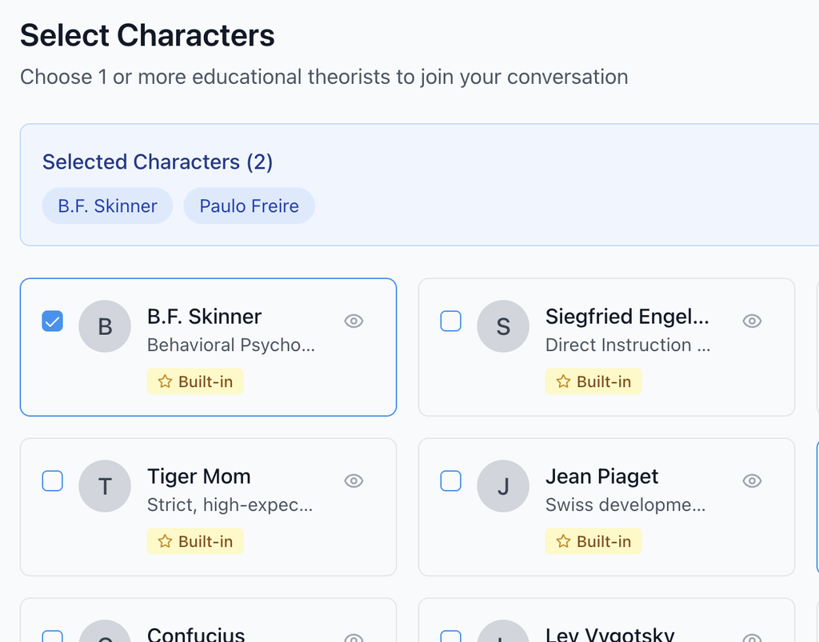

Learner

### ChatLab

Students pick theorists to “join” a conversation about a problem they care about.

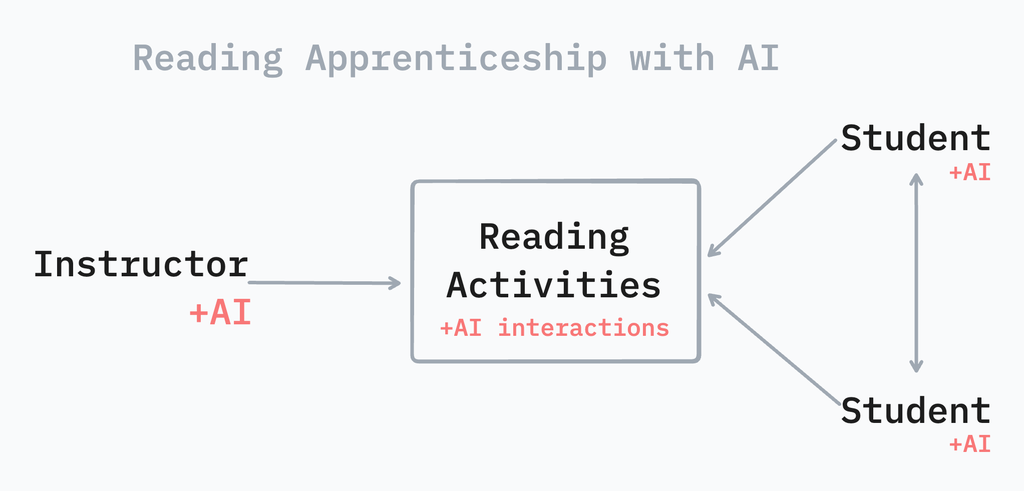

TA / Instructor

### InkSpire

Generates reading scaffolds tied to specific learning goals and disciplinary practices. Something I value but rarely had time to do well for every reading.

## Making thinking visible AI *proposes*. Students *decide*.

In **WonderBits**, a knowledge-building space, AI assistants suggest connections between ideas. Students accept or reject them.

Each decision becomes a **record of student judgment** that teachers and researchers can look at.

TA / Instructor Researcher

Student idea Groups that build on each other’s ideas seem to trust each other more.

AI assistant · suggestion This looks related to the note on shared roles. Link them?

✓ Link ✕ Not quite

→ “Not quite: that note is about roles, mine is about trust.”

Illustrative sketch

## Where the benefits are real Five benefits, when purpose comes first

Learner

### Access to authentic practice

Professionals in many fields already work with AI. Practice the field as it is becoming.

Learner

### Personal connection to hard ideas

Link abstract theory to what you care about.

TA / Instructor

### Scaffolding at scale

Goal-aligned support for every reading, not just some.

Instructor Researcher

### Making thinking visible

Accept/reject decisions leave a record of judgment.

Everyone

### Students as builders, not just users

It’s now realistic for students and teachers to prototype their own tools. That changes **who gets to shape learning environments.**

03 Tensions The central tension is about agency

Who is doing *the thinking?*

Who designs *the environment* where thinking happens?

## Tensions What pulls against what

Offloading Learning

Efficiency Epistemic agency

Surveillance Trust

Homogenization Diversity of ideas

Speed Rigor

## Tensions Two structural questions

Equity

### Who can pay, and who knows how?

Access to paid tools is unequal. So is know-how about using them well. Name it. Where possible, use tools the institution provides.

Design

### Who builds the tools?

Most AI in schools is built by companies with their own goals. Educators and learners are rarely at the design table.

The question isn’t *AI or no AI.* It’s architecture: we are always building environments for thinking, and AI is now part of the material.

04 What to do Be purposeful, be transparent, and put yourself in the designer’s seat

## For everyone Three habits

1

### Start with the goal, not the tool

Ask “what am I trying to learn or teach here?” before “which AI should I use?”

2

### Be transparent

Say when and how you used AI. Transparency builds trust; policing drives use underground.

3

### Keep the judgment calls

Let AI propose; you decide. Practice rejecting outputs, and saying why.

## Transparency in practice What it looks like on the page

From my syllabus

Generative AI tools can enhance your learning when used thoughtfully. **AI should supplement, not substitute for, your own critical thinking.**

If you use one of these tools you will not be penalized. Instead, acknowledge when and where you used it.

For your research: keep a short AI log

| When | Task | What AI did | My call |
| --- | --- | --- | --- |
| Wk 2 | Literature search | Suggested search terms | Kept two; one was off-topic |
| Wk 4 | Interview coding | Proposed initial codes | Merged and renamed; memo on why |
| Wk 6 | Chapter 2 draft | Flagged unclear transitions | Rewrote them myself |

It will help you answer methods questions later, while norms keep shifting.

## By role Wearing each hat

As a learner

- Use AI to get unstuck, to argue with you, and to test your understanding
- Be careful using it to produce the thing you’re supposed to learn to produce

As a researcher

- Keep a log of how you use AI
- Talk with your advisor early about expectations
- Treat validity and reproducibility as open questions, because they are

As a TA / instructor

- Revisit objectives: some should change, some shouldn’t. Decide on purpose.
- Model it: show how you use AI, and where you don’t
- Different courses need different approaches

Build, *don’t just adopt.*

With today’s tools, a doctoral student can prototype a small learning tool in a weekend. That’s a research opportunity *and* a teaching one.

↻ Roundtable 30 minutes: talk, see, try, commit

## Roundtable · 30 min How we’ll spend the time

5

### Quick round

Your hat right now. One use, one worry.

10

### Show and tell

A quick look at one or two tools, with a screenshot backup if the wifi doesn’t cooperate.

10

### Try a prompt together

Pick one and run it live on something someone brings.

5

### Wrap

One change you’ll try this semester.

Quick round

Which hat are you wearing *right now?*

One way you use AI. One worry.

Learner TA / Instructor Researcher

## Show and tell Tools on the table

TA / Instructor

### InkSpire

Reading scaffolds tied to learning goals. Good for preparing discussion.

Learner Researcher

### WonderBits

Knowledge-building canvas. AI proposes, students accept or reject.

Learner

### ChatLab

Connect learning theories to your own interests.

Course design

### Copilot in intro programming

Changing learning objectives on purpose.

Not AI

### Hypothesis

Annotate readings together, then compare your annotations with an AI’s reading.

General

### Claude, ChatGPT, Gemini

Set up with custom instructions as a course tutor or writing partner.

## If things go quiet Questions to sit with

Which part of your own learning would you *not* want AI to do for you? Why?

Should your field’s doctoral training change because of AI? What should *stay the same?*

If you could design one AI tool for your students, what would it do, and what would it *refuse* to do?

Treat AI as part of the environment you design for thinking, and make sure you, and your students, *stay the designers.*

cbd@upenn.edu · bchen.net · [Wonder Lab](https://penn-wonderlab.github.io/)

## Backup Quick answers

Should I use AI to write my dissertation? Use it to think with, not to think for you. Be transparent, check program and advisor norms, keep a log. Your contribution is your judgment and argument.

Is AI detection reliable? No. It produces false positives and erodes trust. Design assignments and norms instead.

How do I write a course AI policy as a TA? Align with the instructor, then state the purpose, what’s allowed, and how to disclose. Short and clear beats long and legalistic.

Which tool should I use? Depends on the task. Start from the learning goal. The prompt and purpose matter more than the brand.

Won’t students just cheat? Some will, as before AI. Transparency norms and assignments tied to process, reflection, and authentic problems reduce the incentive.

What about equity? Name it. Where possible, use tools the institution provides so access isn’t tied to who can pay.